# General Social Survey

Corine Romero

October 14, 2019

# 1 Introduction Question 1

This data is from the 2018 General Social Survey. The first blocks of R-code has selected down a subset of the data to just 15 variables. It has further removed unwanted factor levels in much of the data. Examine that code to see what it is doing. Finally address this question. Is opinion on the death penalty (CAPPUN) independent of gun ownership (OWNGUN)?

## 1.1 Methods

Both variables in this analysis are categorical; hence we use bar graphs and tables to summarize the data, and a chi-squared test for inference.

$H_0$ : There is not relationship between gun ownership and whether one is in favor of capitol punishment.

$H_0$ : There is a relationship between gun ownership and whether one is in favor of Capitol punishment.

## 1.2 Results

### 1.2.1 Descriptive Results

#### 1.2.1.1 Graphical Descriptive Results

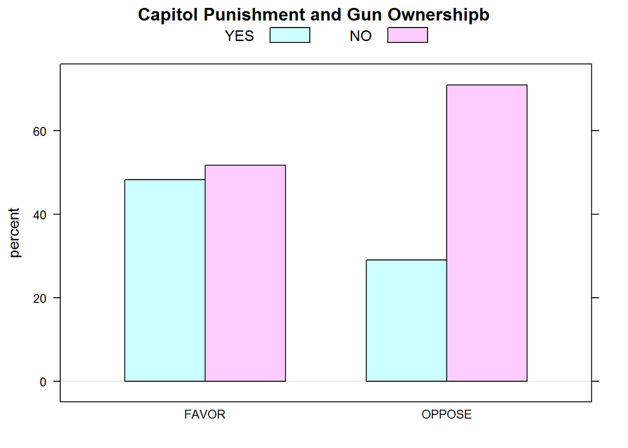

```r
barchartGC(~CAPPUN+OWNGUN, data=mydata4, main='Capitol Punishment and Gun Ownershipb', type= 'percent')
```

This bar chart shows that those who favor capital punishment and own guns are about equal, but there are more who do not own a gun than oppose Capitol punishment. The bar chart indicates there is a connection between gun ownership and supporting capitol punishment, because those in favor and own guns are about equal.

```r
tab1= xtabs(formula = ~CAPPUN+OWNGUN, data=mydata4,)
rowPerc(tab1)
```

```
##         OWNGUN
## CAPPUN      YES     NO  Total
##   FAVOR   48.28  51.72 100.00
##   OPPOSE  29.03  70.97 100.00
```

### 1.2.2 Inferential Results

```r
chisqtestGC(tab1)
```

```
## Pearson's Chi-squared test with Yates' continuity correction
##
## Observed Counts:
##         OWNGUN
## CAPPUN   YES NO
##   FAVOR   56 60
##   OPPOSE  18 44
##
## Counts Expected by Null:
##         OWNGUN
## CAPPUN     YES    NO
##   FAVOR  48.22 67.78
##   OPPOSE 25.78 36.22
##
## Contributions to the chi-square statistic:
##         OWNGUN
## CAPPUN    YES   NO
##   FAVOR  1.25 0.89
##   OPPOSE 2.35 1.67
##
##
## Chi-Square Statistic = 5.3932
## Degrees of Freedom of the table = 1
## P-Value = 0.0202
```

The P-value is 0.02 < 0.05 so we reject the null hypothesis and conclude we have evidence to support the connection that gun ownership and whether one favors capitol punishment are related. The bar chart indicates there is a connection between gun ownership and supporting capitol punishment.

# 2 Introduction Question 2

Now answer Is belief in the big bang theory (BIGBANG) independent of belief in the afterlife (POSTLIFE)

## 2.1 Methods

Both variables in this analysis are categorical; hence we use bar graphs and tables to summarize the data, and a chi-squared test for inference.

$H_0$ : There is no relationship between Big bang theory and whether one believes in the afterlife.

$H_0$ : There is a relationship between belief in the big bang theory and the belief in the afterlife.

## 2.2 Results

### 2.2.1 Descriptive Results

#### 2.2.1.1 Graphical Descriptive Results

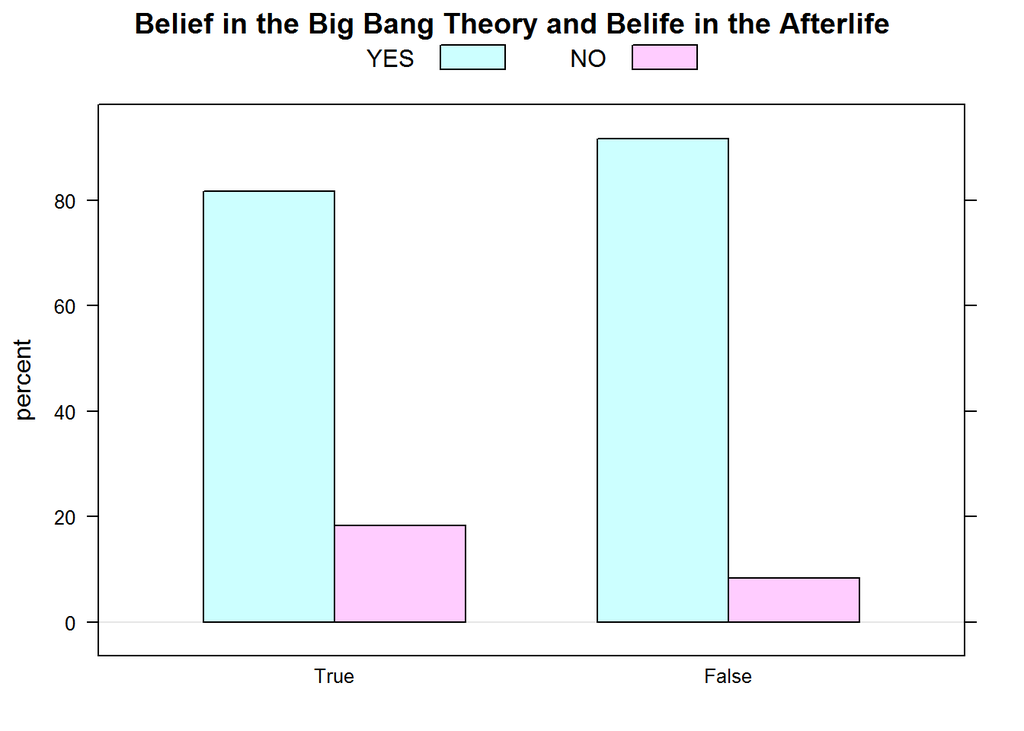

```r
barchartGC(~BIGBANG+POSTLIFE, data=mydata4, main='Belief in the Big Bang Theory and Belife in the Afterlife', type= 'percent')
```

The bar chart shows that there is no relationship between in belief in the big bang theory and the belief in afterlife since in both cases there is not a lot of change in the data sets.

#### 2.2.1.2 Numerical Descriptive Results

```r
tab2= xtabs(formula = ~BIGBANG+POSTLIFE, data=mydata4,)
rowPerc(tab2)
```

```
##        POSTLIFE
## BIGBANG    YES     NO  Total
##   True   81.71  18.29 100.00
##   False  91.67   8.33 100.00
```

### 2.2.2 Inferential Results

```r
chisqtestGC(tab2)
```

```
## Pearson's Chi-squared test with Yates' continuity correction
##
## Observed Counts:
##        POSTLIFE
## BIGBANG YES NO
##   True   67 15
##   False  88  8
##
## Counts Expected by Null:
##        POSTLIFE
## BIGBANG  YES   NO
##   True  71.4 10.6
##   False 83.6 12.4
##
## Contributions to the chi-square statistic:
##        POSTLIFE
## BIGBANG  YES   NO
##   True  0.27 1.83
##   False 0.23 1.56
##
##
## Chi-Square Statistic = 3.0637
## Degrees of Freedom of the table = 1
## P-Value = 0.0801
```

The p-value is 0.08 > 0.05 so we fail to reject the null hypothesis and conclude we do not have evidence to support the connection. The bar chart does not support a connection between belief in the big bang theory and belief in the afterlife.

# 3 Introduction Question 3

Finally determine if a persons opinion on death penalty (CAPPUN) is independent of their race (RACE).

## 3.1 Methods

Both variables in this analysis are categorical; hence we use bar graphs and tables to summarize the data, and a chi-squared test for inference.

$H_0$ : There is no relationship between death penalty and race.

$H_0$ : There is a relationship between opinion on the death penalty and race.

## 3.2 Results

### 3.2.1 Descriptive Results

#### 3.2.1.1 Graphical Descriptive Results

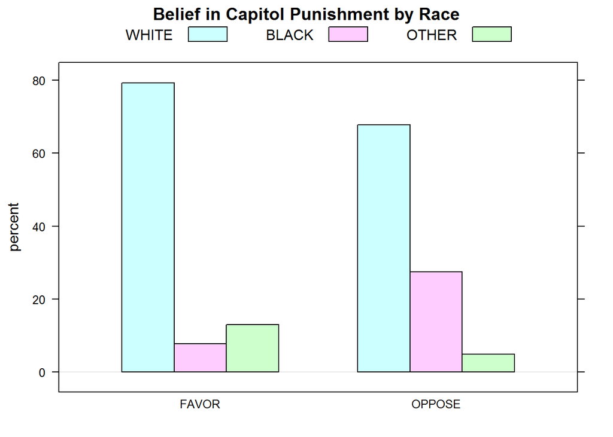

```r
barchartGC(~CAPPUN+RACE, data=mydata4, main='Belief in Capitol Punishment by Race', type= 'percent')
```

The bar chart showed that there is a connection between belief in capitol punishment and race. since whites favor capitol punishment and blacks oppose capitol punishment.

#### 3.2.1.2 Numerical Descriptive Results

```r
tab3= xtabs(formula = ~CAPPUN+RACE, data=mydata4,)
rowPerc(tab3)
```

```
##         RACE
## CAPPUN    WHITE  BLACK  OTHER  Total
##   FAVOR   79.31   7.76  12.93 100.00
##   OPPOSE  67.74  27.42   4.84 100.00
```

### 3.2.2 Inferential Results

```r
chisqtestGC(tab3)
```

```
## Pearson's Chi-squared test
##
## Observed Counts:
##         RACE
## CAPPUN   WHITE BLACK OTHER
##   FAVOR     92     9    15
##   OPPOSE    42    17     3
##
## Counts Expected by Null:
##         RACE
## CAPPUN   WHITE BLACK OTHER
##   FAVOR  87.33 16.94 11.73
##   OPPOSE 46.67  9.06  6.27
##
## Contributions to the chi-square statistic:
##         RACE
## CAPPUN   WHITE BLACK OTHER
##   FAVOR   0.25  3.72  0.91
##   OPPOSE  0.47  6.97  1.71
##
##
## Chi-Square Statistic = 14.0272
## Degrees of Freedom of the table = 2
## P-Value = 9e-04
```

# 4 Discussion and Conclusion

Question #1, Is about the opinion on the death penalty (CAPPUN) is independent of gun ownership (OWNGUN)? The p-value is 0.02 < 0.05 so we reject the null hypothesis and conclude that we have the evidence to support the connection between gun ownership and capital punishment are related.

Question #2, Is the belief in the big bang theory independent of belief in the afterlife? The p-value is 0.08 > 0.05 so we have failed to reject the null hypothesis and conclude we do not have enough evidence to support a connection between the belief in the big bang theory and the beige in after life.